# Visualisation avec

### La couche *theme* du package [{ggplot2}](https://ggplot2.tidyverse.org/)

**Elle permet de personnaliser l’apparence d’un graphique en modifiant les éléments visuels qui ne sont pas directement liés aux données**

- titres
- étiquettes
- polices
- arrière-plan
- grilles
- légendes
- tailles
- etc.

On utilise pour cela la fonction principale `theme()`  
On utilise des sous-fonctions de type `element_*()`, pour ajuster les éléments particuliers du graphique

#### Utiliser un thème prédéfini

- **Les différents thèmes qui existent**

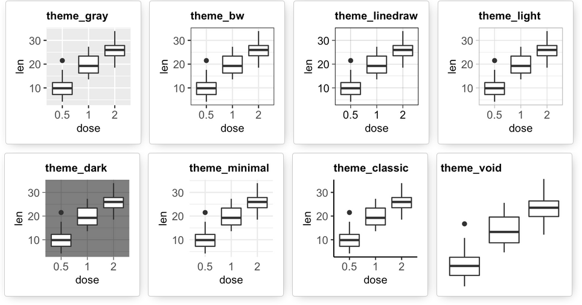

- **Exemple d’utilisation**

**Afficher le code**

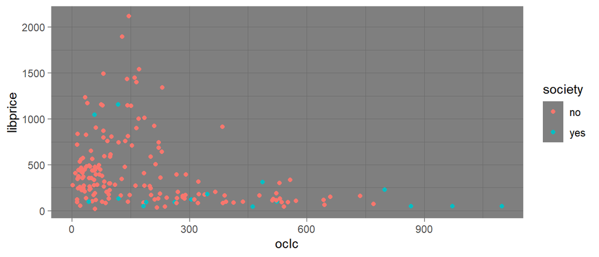

```r
# Nuage de points avec le theme Dark
ggplot(data = Journals) +
  aes(x = oclc, y = libprice,
      colour = society) +
  geom_point() +
  theme_dark()
```

On peut définir le thème pour toute la durée de la session avec `theme_set()`

**Afficher le code**

```r
# Thème Dark pour tous les plots
theme_set(theme_dark())

ggplot() +
  ...
```

Les graphiques seront tous réalisés avec le thème indiqué dans `theme_set()`

#### Éditer un thème existant

Il est possible de modifier un thème existant, en utilisant la fonction `theme_update()` du package [{ggplot2}](https://ggplot2.tidyverse.org/)

**Afficher le code**

```r
# Personnalisation du thème
theme_update(panel.grid.major = element_line(color = "grey80"), # couleur de la grille principale
             panel.grid.minor = element_line(colour = "black",  # couleur de la grille secondaire
                                             linewidth = 1),    # épaisseur de la grille secondaire
             panel.background = element_rect(fill = "white"),   # couleur de fond
             text = element_text(family = "sans", size = 14),   # taille du texte
             plot.title = element_text(color = "#275662"        # couleur du titre
                                       , face = "bold"),        # police en gras
             axis.title.x = element_text(color = "purple"),     # couleur du label de l'axe des abscisses
             axis.title.y = element_text(size = 20,             # taille
                                         color = "blue"))       # et couleur du label de l'axe des ordonnées
```

**Afficher le code**

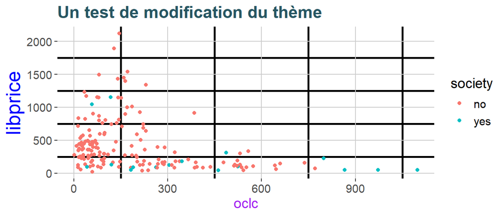

```r
# Réalisation du graphique avec ces modifications
ggplot(data = Journals) +
    aes(x = oclc,
        y = libprice,
        colour = society) +
    geom_point() +
  ggtitle("Un test de modification du thème")
```

**Theme_update() : change le thème global**  
Tous les graphiques créés après utiliseront ces paramètres par défaut

#### Vous ne savez pas comment modifier les paramètres d’un thème ?

L’interface “clic bouton” de [{ggThemeAssist}](https://github.com/calligross/ggthemeassist) peut vous aider

**Comment ça marche ?**

1. Sélectionner le code du graphique
2. Lancer la commande `ggThemeAssistGadget()` ou utiliser le menu *Addins* et sélectionner `ggplot2 Theme Assistant`
3. Modifier les paramètres (taille des titres, angle des étiquettes, position de la légende, couleurs de fond, etc.), à l’aide des rubriques dans les différents onglets
4. Cliquer sur ‘*Done*’ pour valider : le code `theme(...)` correspondant aux modifications est inséré automatiquement dans le script

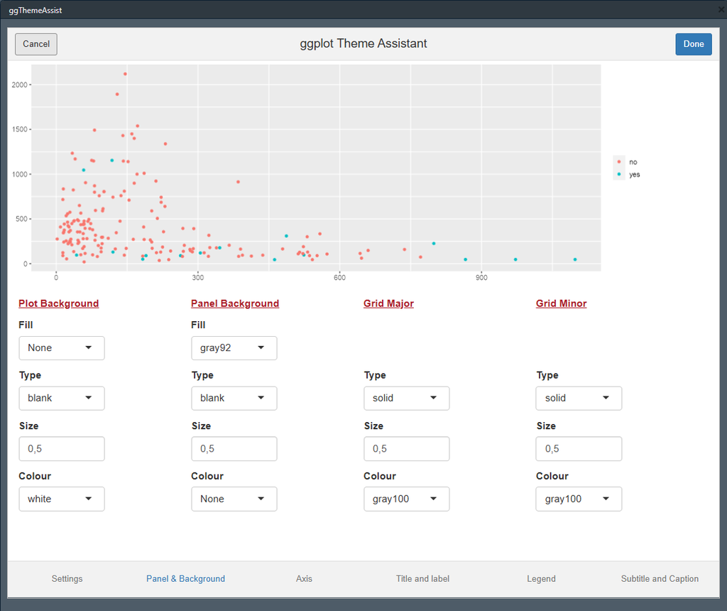

```r
# Création du graphique
# en lui donnant un nom sans "_" (erreur sinon)
plotolclibprice <- ggplot(data = Journals) +
  aes(x = oclc,
      y = libprice,
      colour = society) +
  geom_point()

# Modification du thème pour ce graphique
ggThemeAssistGadget(plotolclibprice)
```

#### Créer et utiliser son propre thème

Utile pour personnaliser l’apparence des graphiques, en ajustant divers éléments : titres, étiquettes, polices, arrière-plan, quadrillages et légendes

*Exemple*

**Afficher le code**

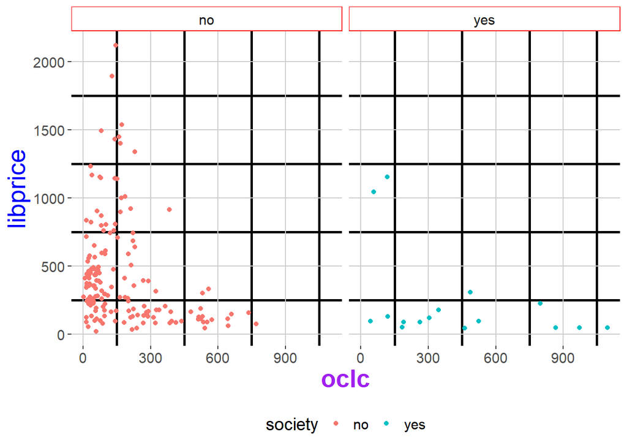

```r
# Création du thème
theme(axis.title.x = element_text(size = 20,
                                  face = "bold"),
      strip.background = element_rect(colour = "red",
                                      fill = "white"),
      legend.position = "bottom") -> themeperso

# Utilisation du thème
ggplot(data = Journals) +
  aes(x = oclc, y = libprice, colour = society) +
  geom_point()  +
  facet_wrap(vars(society)) +
  themeperso
```

Se reporter à la section [*theme*](https://ggplot2-book.org/themes) de Wickham (2016) pour plus de détails

## À VOUS DE JOUER !

**Exercice 4** Pour cet exercice, on se place toujours dans le projet **`VisuR_exercices`**, et on crée un nouveau script pour les explorations graphiques avancées avec {`ggplot2`}  
On va s’intéresser au taux de chômage, aux revenus et aux émissions totales de CO2, par région, pour toutes les années

1. Créer un nouveau script **[R]** pour ces analyses graphiques avancées
2. Sélectionner les données nécessaires pour l’exercice et les stocker dans l’objet `communes_ex4`
3. Construire les *boxplot* du taux de chômage par région, toutes années confondues, avec un titre, la source (en bas) et le `theme_bw()`
4. On s’intéresse à la relation entre revenus et émissions de CO2/hab pour les régions Nouvelle-Aquitaine, Occitanie, Bretagne, Pays de la Loire et Grand Est
   - créer le nuage de points `revenu_median` x `emis_co2_total`
   - utiliser les facettes pour avoir une facette par `annee`
   - les points ont des couleurs différentes selon la région

*Solution 4*. **Script 02_ggplots_Exercices_VisuR.R**

**Afficher le code**

```r
#   ____________________________________________________________________________
#   Exercice sur les graphiques avancés avec ggplot2                        ####

#   01. Nom du script : 02_ggplots_Exercices_VisuR.R

##  ............................................................................
##  Packages                                                                ####

library(ggplot2)    # v4.0.3

##  ............................................................................
##  02. Sélection des données                                               ####
communes_ex4 <- communes |>
  select(CODGEO, commune,                                             # variables d'identification des observations
          region, annee, taux_chomage, revenu_median, emis_co2_total) # variables pour l'exercice

##  ............................................................................
##  03. Boxplot du taux de chômage par année toutes régions confondues  ####
ggplot(communes_ex4) +                           # initialisation du graphique
  aes(x = region, y = taux_chomage) +            # données à représenter
  geom_boxplot(fill = "darkgreen") +             # type de graphique : boxplot
  labs(title = "Taux de chômage par région (années 2018, 2020 et 2022 confondues)",
       caption = "Source : données fictives") +
  theme_bw() +                         # thème
  theme(axis.text.x = element_text(angle = 90))  # rotation des libellés pour une meilleure lisibilité

##  ............................................................................
##  04. Relation entre revenus et émissions de CO2 selon l'année            ####

# Sélection des données
communes_ex4 |>
  filter(region %in% c("Nouvelle-Aquitaine", "Occitanie", "Bretagne", "Pays de la Loire", "Grand Est")) |>
# Plot
  ggplot() +                                              # initialisation du graphique
  aes(x = revenu_median, emis_co2_hab, color = region) +  #  données à représenter
  geom_point() +                                          # type de graphique : nuage de points
  facet_wrap(vars(annee)) +                               # facettes par année
    labs(title = "Émissions de CO2 en fonction du revenu médian",
         caption = "Source : données fictives",
         x = "Revenu médian",
         y = "Émissions de CO2 (t eq. CO2/hab/an)")
  theme(legend.position = "bottom")                       # personnalisation : légende sous le graphique
```

# Bibliographie

### Références citées

Orozco, V., Bontemps, C., Maigné, E., Piguet, V., Hofstetter, A., Lacroix, A., Levert, F., & Rousselle, J.-M. (2020). How To Make A Pie: Reproducible Research for Empirical Economics and Econometrics. *Journal of Economic Surveys*, *34*(5), 1134‑1169. https://doi.org/10.1111/joes.12389

Wickham, H., & Grolemund, G. (2018). *R pour les data sciences : importer, classer, transformer, visualiser et modéliser les données*. Eyrolles. https://r4ds.had.co.nz/

Wilkinson, L. (1999). *The Grammar of Graphics* (1st éd.). Springer New York, NY. https://doi.org/10.1007/978-1-4757-3100-2

Wilkinson, L. (2005). *The Grammar of Graphics* (2nd éd.). Springer New York, NY. https://doi.org/10.1007/0-387-28695-0

### Packages

Bache, S. M., & Wickham, H. (2026). *magrittr: A Forward-Pipe Operator for R*. https://magrittr.tidyverse.org

Barbone, J. M., & Garbuszus, J. M. (2026). *openxlsx2: Read, Write and Edit xlsx Files*. https://janmarvin.github.io/openxlsx2/

Barnier, J., Briatte, F., & Larmarange, J. (2026). *questionr: Functions to Make Surveys Processing Easier*. https://juba.github.io/questionr/

Croissant, Y., & Graves, S. (2025). *Ecdat: Data Sets for Econometrics*. https://www.r-project.org

Csárdi, G., Hester, J., Wickham, H., Chang, W., Morgan, M., & Tenenbaum, D. (2024). *remotes: R Package Installation from Remote Repositories, Including GitHub*. https://remotes.r-lib.org

Dragulescu, A., & Arendt, C. (2020). *xlsx: Read, Write, Format Excel 2007 and Excel 97/2000/XP/2003 Files*. https://github.com/colearendt/xlsx

Grolemund, G., & Wickham, H. (2011). Dates and Times Made Easy with lubridate. *Journal of Statistical Software*, *40*(3), 1‑25. https://www.jstatsoft.org/v40/i03/

Hester, J., Angly, F., Chirico, M., Hyde, R., Kun, R., Patil, I., & Rosenstock, A. (2025). Static Code Analysis for R. *Journal of Open Source Software*, *10*(108), 7240. https://doi.org/10.21105/joss.07240

Hester, J., Angly, F., Hyde, R., Chirico, M., Ren, K., Rosenstock, A., Patil, I., Gruson, H., & Ferdman, E. (2026). *lintr: A Linter for R Code*. https://lintr.r-lib.org

Müller, K., Walthert, L., & Patil, I. (2025). *styler: Non-Invasive Pretty Printing of R Code*. https://github.com/r-lib/styler

Müller, K., & Wickham, H. (2026). *tibble: Simple Data Frames*. https://tibble.tidyverse.org/

Ooms, J. (2025). *writexl: Export Data Frames to Excel xlsx Format*. https://ropensci.r-universe.dev/writexl

R Core Team. (2026). *foreign: Read Data Stored by Minitab, S, SAS, SPSS, Stata, Systat, Weka, dBase, ...* https://svn.r-project.org/R-packages/trunk/foreign/

Spinu, V., Grolemund, G., & Wickham, H. (2026). *lubridate: Make Dealing with Dates a Little Easier*. https://lubridate.tidyverse.org

Walthert, L. (2026). *strcode: Structure and abstract your code*. https://github.com/lorenzwalthert/strcode

Wickham, H. (2016). *ggplot2: Elegant Graphics for Data Analysis*. Springer-Verlag New York. https://ggplot2.tidyverse.org

Wickham, H. (2023). *tidyverse: Easily Install and Load the Tidyverse*. https://tidyverse.tidyverse.org

Wickham, H. (2025a). *forcats: Tools for Working with Categorical Variables (Factors)*. https://forcats.tidyverse.org/

Wickham, H. (2025b). *stringr: Simple, Consistent Wrappers for Common String Operations*. https://stringr.tidyverse.org

Wickham, H., Averick, M., Bryan, J., Chang, W., McGowan, L. D., François, R., Grolemund, G., Hayes, A., Henry, L., Hester, J., Kuhn, M., Pedersen, T. L., Miller, E., Bache, S. M., Müller, K., Ooms, J., Robinson, D., Seidel, D. P., Spinu, V., … Yutani, H. (2019). Welcome to the tidyverse. *Journal of Open Source Software*, *4*(43), 1686. https://doi.org/10.21105/joss.01686

Wickham, H., & Bryan, J. (2026). *readxl: Read Excel Files*. https://readxl.tidyverse.org

Wickham, H., Chang, W., Henry, L., Pedersen, T. L., Takahashi, K., Wilke, C., Woo, K., Yutani, H., Dunnington, D., & van den Brand, T. (2026). *ggplot2: Create Elegant Data Visualisations Using the Grammar of Graphics*. https://ggplot2.tidyverse.org

Wickham, H., François, R., Henry, L., Müller, K., & Vaughan, D. (2026). *dplyr: A Grammar of Data Manipulation*. https://dplyr.tidyverse.org

Wickham, H., & Henry, L. (2026). *purrr: Functional Programming Tools*. https://purrr.tidyverse.org/

Wickham, H., Hester, J., & Bryan, J. (2026). *readr: Read Rectangular Text Data*. https://readr.tidyverse.org

Wickham, H., Miller, E., & Smith, D. (2025). *haven: Import and Export SPSS, Stata and SAS Files*. https://haven.tidyverse.org

Wickham, H., Vaughan, D., & Girlich, M. (2025). *tidyr: Tidy Messy Data*. https://tidyr.tidyverse.org